# 欧洲疫情规模预测及境外输入导致的中国疫情二次爆发风险评估

组员：刘晓菡、孙融雪、王帆、程宏宇

2020/4/19

# 现状

距离疫情发生已经过去了近四个月时间了，在这段时间里大家经历了一场前所未有的防疫战斗。  
从2019年12月开始，陆续有武汉市民被确诊为“不明肺炎病症”，2020年1月7日，初步判定该疾病元凶为新型冠状病毒，接着，疫情爆发，专家证实了该病毒具有人传人的性质，武汉发出交通封城通告，全国各地纷纷紧急启动一级响应，国家紧急筹建火神山雷神山医院，各地纷纷向武汉提供紧急援助。截至2020年4月，我国新冠疫情已经基本稳定，多地传来了零新增的好消息，但战斗还远远未结束。

我们通过一些可视化信息来分析到2020年4月我国的疫情状况：

# ①中国疫情现状

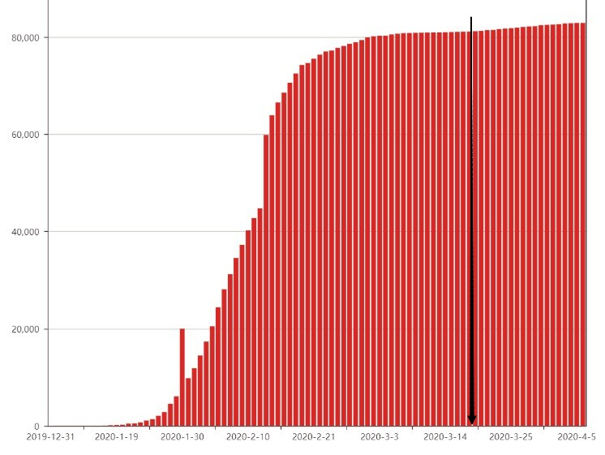

图1：中国新冠肺炎每日累计感染人数时序图（单位：人）

# ②每日新增感染人数组成分析

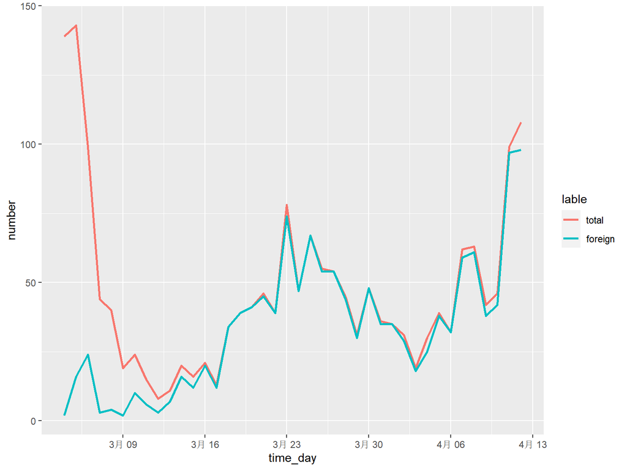

图2：每日新增感染人数与境外输入人数对比（单位：人）

# ③中国境外输入病例分布状况

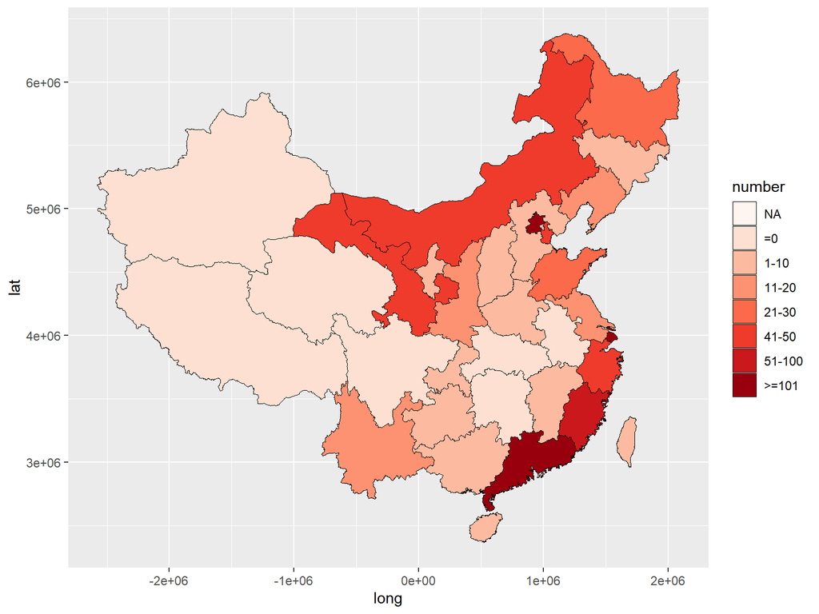

图3：境外病例分布输入状况（截至5/4/2020）

# ④国外疫情状况

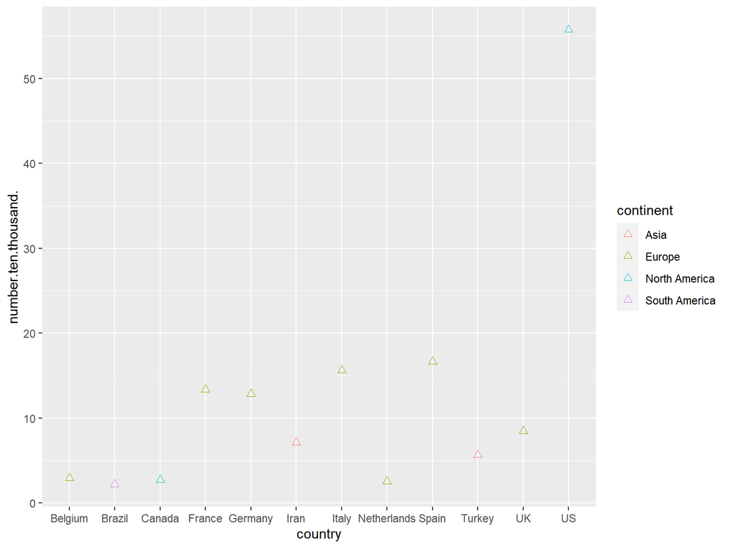

图4：全球新型管状病毒累计感染人数前12个国家的分布（截至12/4/2020）

# 1.内容简介

前期准备：

①模型介绍、文献解读

②欧洲疫情预测及R代码展示

研究成果：

①境外输入导致中国疫情二次爆发状况预测

②结果评价与原因分析

# 2.数据来源

本次研究数据来源于：

①中国卫健委：http://www.nhc.gov.cn/xcs/xxgzbd/gzbd_index.shtml

②意大利卫生部：http://www.salute.gov.it/portale/nuovocoronavirus/archivioComunicatiNuovoCoronavirus.jsp

# 3.文献介绍

*题目：

利用Logistic模型估计冠状病毒COVID19第二期疫情的最终规模

*来源：

https://www.medrxiv.org/content/10.1101/2020.03.11.20024901v2

*发布时间：

2020.03.16

# 3.1 模型介绍

3.1.1 逻辑斯蒂增长模型

逻辑斯蒂增长模型，俗称“S”曲线，又称自我抑制性方程。由Verhulst于1845年提出，用于模拟人口的增长。其特点是开始增长缓慢，而在以后某一时点上开始迅速增长，达到一定水平后，增长速度又逐渐放慢。

该模型将发病百分率转换为逻辑值，在平面坐标图中以逻辑值为纵坐标对时间进行作图。逻辑值与纵轴相交的结点为初始病害数量，逻辑值的斜率为病害流行速度，也就是浸染速率。其与指数模型最重要的不同之处就是方程右边增加修正因子，使模型本身包含自我抑制作用。

# 3.1.1 逻辑斯蒂增长模型

曲线形状大致如图所示：

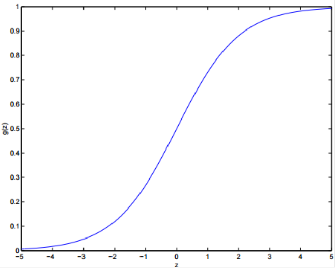

# 3.1.1 逻辑斯蒂增长模型

通常，逻辑斯蒂曲线划分为五个时期：

①开始期。又称潜伏期，此时种群个体数很少，密度 增长缓慢。

②加速器。随着个体数量的增加，密度增长逐渐加快。

③转折期。当个体数 目达到 自然环境可容纳的饱和密度一半时，密度增长最快。

④减速期。现存个体数超过饱和数目一半以后，密度增长逐渐变慢。

⑤饱和期。种群个 体数达到饱和值从而停止 增长。

# 3.1.1 逻辑斯蒂增长模型

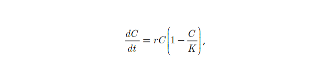

C：累积病例数

r：感染率（大于0）

K：传染病最终规模

# 3.1.1 逻辑斯蒂增长模型

当初始值大于零时，可将式子变形为：

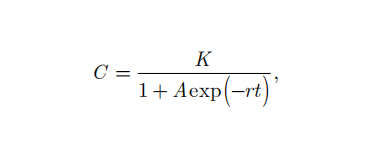

其中，A=(K-C)/C

# 3.1.2 优点

在预测新冠疫情规模的问题中，作者曾将逻辑增长模型与SIR模型预测结果进行比较，发现两者结果精度相差无几，但逻辑增长模型给出了更加明确和简便的算法，而SIR模型对参数的初始值设定依赖较大。

# 3.1.3 缺点

逻辑增长模型内部不嵌套自然法则和原理，故无法描述有关治愈率、无症状感染者等等问题，且模型存在成立的充分条件，即预测的最终规模理论上应该大于当前观测到的累计感染者，否则将强制退出模型。

# 3.2 数学推导

3.2.1 拐点求解

传染病增长率在导数为零将达到最大值，在这个条件下，我们可以得到基于现有数据的增长率高峰时点t及此时的感染规模C和传染率。

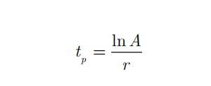

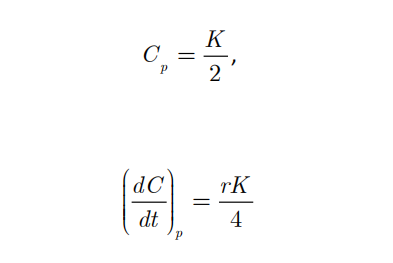

# 3.2 数学推导

3.2.2 初始值确定

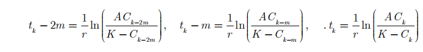

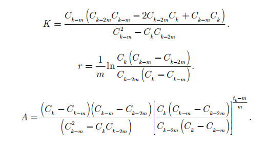

现在，假设我们可以得到n期的患病人数，那么就可以预测各期相应的最终规模，当模型达到收敛状态时(不再满足模型成立条件时)，就可以得出最终结论。

# 3.3 结果分析

表1：中国的逻辑增长模型参数估计值（截至2020.03.11）

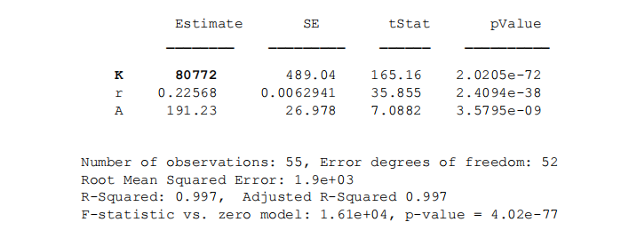

根据可获得的数据，我们可以最终估计出中国新冠疫情的最终规模，约为81000例，误差约为500人左右。

# 3.3 结果分析

表2：中国疫情数据逻辑回归的日模拟结果（截至2020.03.04）

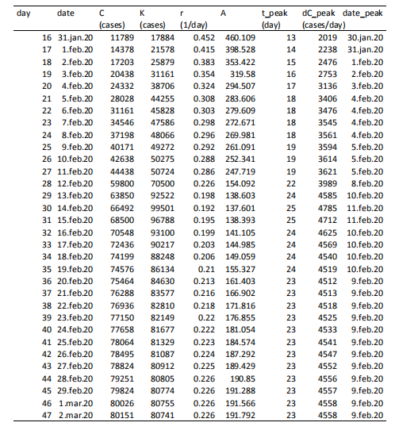

从图中可以看出，新冠疫情高峰大约出现在2020.02.09前后

# 3.3 结果分析

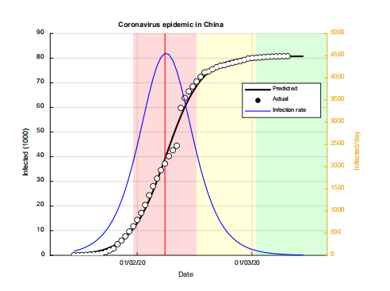

图1：中国新冠疫情数据拟合结果

从图中可以看出，模型预测情况良好，且截至2020.03.11，可以认为中国疫情基本处于结束阶段。

# 3.3 结果分析

表4：模型短期预测结果

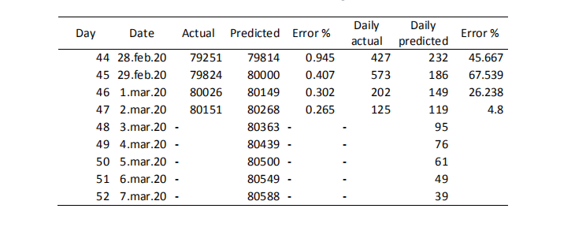

分析：我们可以看到实际和预测病例数的差异在2%以内。至2020年3月7日，预测累计病例数为计80588例，日增病例数为39例。而根据国家卫健委的报告，当日我国累计感染人数为80695人，新增人数为44人。

可以看出模型预测的准确度和鲁棒性都比较好。

# 进一步研究

接下来，我们将以意大利为例来研究欧洲国家疫情发展状况。 首先，我们想要绘制出2020.2.20-2020.4.19的意大利疫情的趋势图（包含时间、累计确诊数、今日新增数、累计死亡数以及累计治愈数）五列，时间为x轴，其他四个变量作为y来绘制散点图。

将excel数据导入，得到数据如下图。共五列：时间、累计确诊数、今日新增数、累计死亡数、累计治愈数。

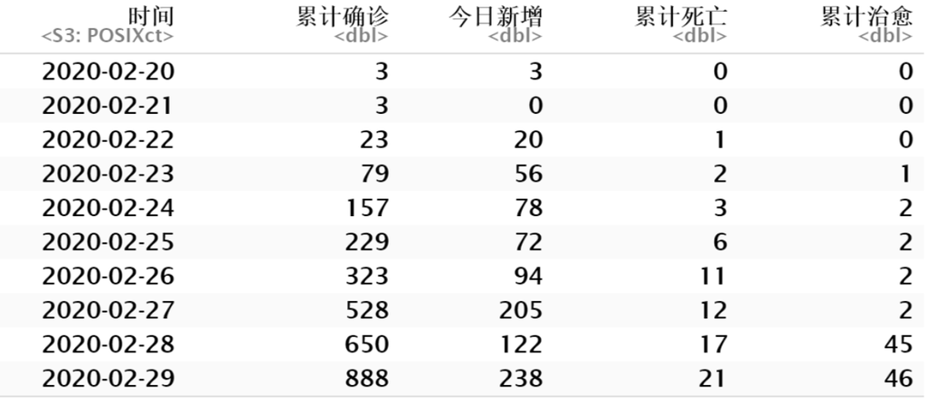

# 作图代码和结果如下：

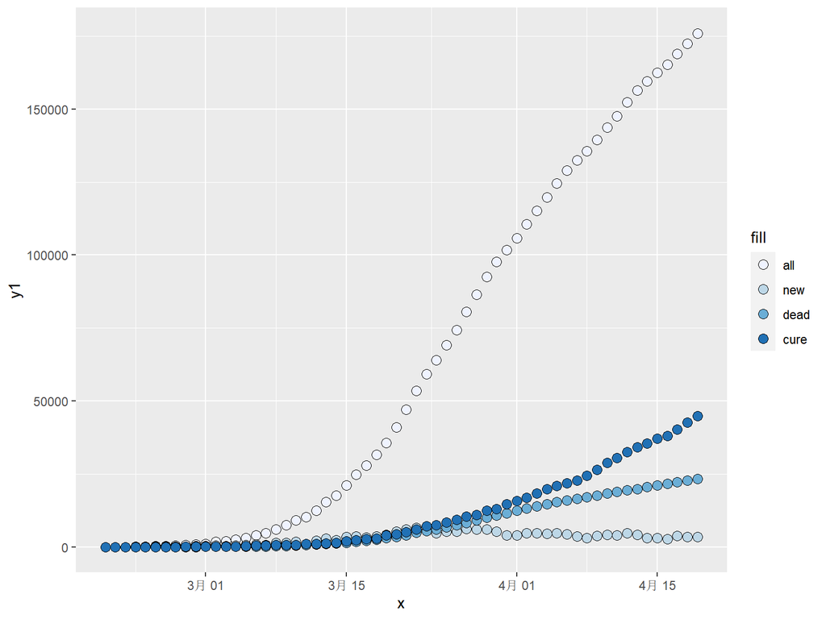

```r
fills=c('all'="blue",'new'="yellow",'dead'="lightpink",'cure'="red")
library(ggplot2)
names(data)<-c("x","y1","y2","y3","y4")
ggplot(data)+geom_point(aes(x,y=y1,fill="all"),size=3,shape=21,color="black")+geom_point(aes(x,y=y2,fill="new"),size=3,shape=21)+
geom_point(aes(x,y=y3,fill="dead"),size=3,shape=21)+
geom_point(aes(x,y=y4,fill="cure"),size=3,shape=21)+
scale_fill_brewer(limits=c('all','new','dead','cure'))+
theme(plot.title = element_text(hjust = 0.5))
```

上图为意大利的疫情趋势图，可以看出意大利的累计确诊数已经开始逐渐趋于放缓，每日新增人数也开始逐渐减少。累计治愈人数开始逐渐变多且增长的速度逐渐变快。而累计死亡人数的增速也开始放缓，意大利疫情开始呈现出收敛的态势。 而后通过逻辑斯蒂增长模型对意大利疫情进行预测。

# **Logistic增长模型估计意大利疫情**

在对意大利疫情进行估计的过程中，首先将数据进行导入。选取了2020.2.20-2020.4.19共60天数据。数据分别用m,n来表示。它们分别代表时间以及累积确诊病例数。在这里，m表示疫情爆发的天数（共60天）。将这两列数据合并为df。

下表展示了合并之后的数据df。

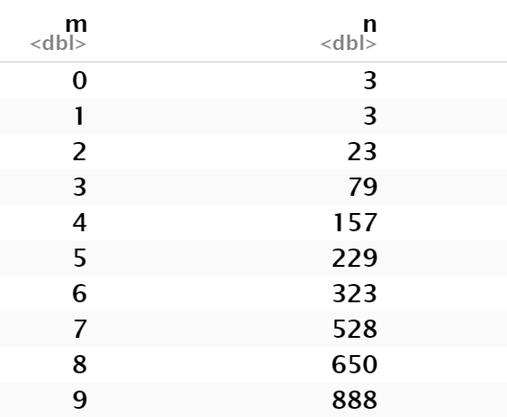

# 计算参数初始值

在数据导入结束后，为了进行后续的预测，需要对参数的初始值进行估计。论文中给出了参数初始值的估计方法。

首先，我们整体观察初始值的计算公式：

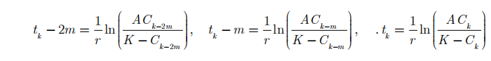

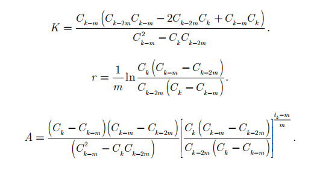

在确定参数的时候，论文中表示，选取第一个数据、中间数据以及最后一个数据来计算初值。C为累计确诊病例数。因此，首先计算出这三个位置的数据值。并分别取名为c_max，c_median,c_min。他们分别对应公式中的

$C_k$,$C_{k-m}$,$C_{k-2m}$

# 计算得出这三个值如下

| name | 数值 |
| --- | --- |
| $C_k$ | 175925 |
| $C_{k-m}$ | 44028 |
| $C_{k-2m}$ | 3 |

# 进一步计算初始值k0,r0,n0

根据以下两个公式首先计算出k0，r0。

其中，由于

$C_k$,$C_{k-m}$,$C_{k-2m}$

分别代表的是最大值，中值，最小值。而他们的下角标为k,k-m,k-2m。因此，m是由数据长度除以2来表示的。将这四个值代入下述两个式子计算得到K0，r0。

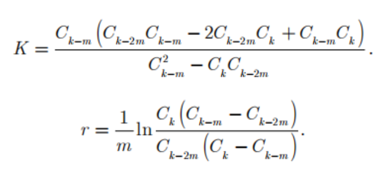

求得k0，r0后，再根据

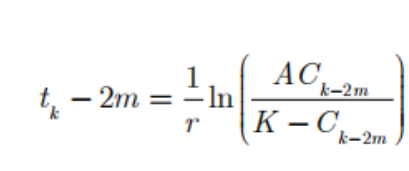

计算出A的值。A与C0之间存在一定的数量关系。从而可以倒推出C0的取值。

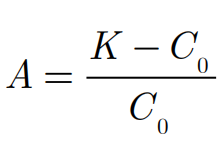

# 整个计算过程的代码如下：

```r
K_start=c_median*(c_min*c_median-2*c_min*c_max+c_median*c_max)/((c_median**2)-c_max*c_min)
m=length(n)/2
t=length(n)
R_start=(1/m)*log10(c_max*(c_median-c_min)/(c_min*(c_max-c_median)))

A_start=((K_start-c_median)*exp((t-m)*R_start))/c_median
N0_start=K_start/(A_start+1)
A_start
K_start
R_start
N0_start
```

最后计算初始参数值如下：

| 初始参数 | 数值 |
| --- | --- |
| $A_0$ | 218.9997 |
| $K_0$ | 175951.9 |
| $R_0$ | 0.1430557 |
| $N_0$ | 799.7825 |

# 最小二乘法拟合

初始值计算出后，利用最小二乘法来进行拟合估计参数

得到最后估计的参数值

[output not shown]

因此，我们可以最终估计出意大利新冠疫情的最终规模，约为177500例，误差约为2500人左右。

# 绘制增长曲线

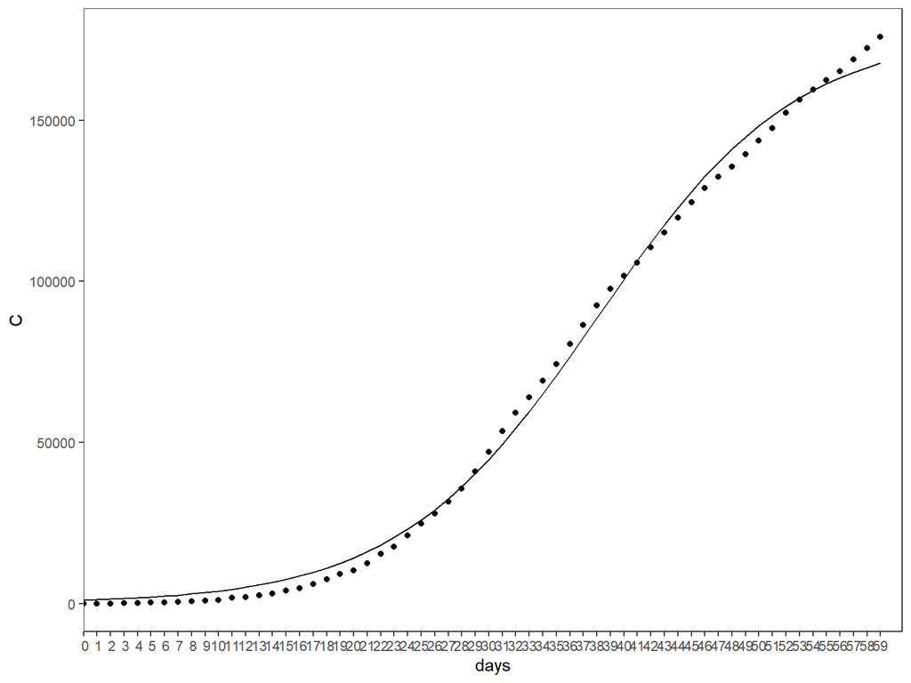

上图中，散点图代表的是真实值，而折线图代表的是预测值。可以看出，预测曲线对真实值的拟合度较好。两者基本接近。

# 下表展示了4月5日-4月19日的预测值和真实值

| 日期 | 真实值 | 预测值 |
| --- | --- | --- |
| 4月5日 | 124632 | 127866.805 |
| 4月6日 | 128948 | 132568.343 |
| 4月7日 | 132547 | 136965.73 |
| 4月8日 | 135586 | 141051.104 |
| 4月9日 | 139422 | 144822.985 |
| 4月10日 | 143626 | 148285.411 |
| 4月11日 | 147577 | 151446.991 |
| 4月12日 | 152271 | 154319.943 |
| 4月13日 | 156363 | 156919.171 |
| 4月14日 | 159516 | 159261.422 |
| 4月15日 | 162488 | 161364.551 |
| 4月16日 | 165155 | 163246.904 |
| 4月17日 | 168941 | 164926.809 |
| 4月18日 | 172434 | 166422.188 |
| 4月19日 | 175925 | 167750.267 |